# bails-and-statutes.Rmd

Nathan Kendsersky

4/15/2021

### Load Packages and Functions

```r
# packages to load
library(tidyverse)
```

```r
library(skimr)
library(ggsci)
library(ggpubr)
library(cowplot)
library(reshape2)
require(scales)
library(lubridate)
# functions to load
`%notin%` <- Negate(`%in%`)
```

### Load Data

Load raw (offenses, docket details) and cleaned (docket charges) datasets.

```r
# load raw dataset, for statutes
offenses_dispo <- readRDS("reports/data/raw/offenses_dispositions.Rds") %>%
  dplyr::select(-c("disposing_authority__first_name","disposing_authority__middle_name","disposing_authority__last_name",
                   "disposing_authority__title","disposing_authority__document_name"))
docket_details <- readRDS("reports/data/raw/defendant_docket_details.Rds") %>%
  dplyr::select(docket_id,gender,race,filing_date) %>%
  dplyr::filter(between(year(filing_date), 2016, 2019)) %>% # select 2 years before and 2 years after
  mutate(filing_year = year(filing_date),
         timeframe = ifelse(filing_year < 2018, "before", "after")) # 2016/2017 are "pre_Krasner", 2018/2019 are "post"
offenses_details <- merge(offenses_dispo,docket_details,by="docket_id")

# load cleaned dataset (run clean_data.R, then save_data.R, both are in the data directories), for bail/sentencing
docket_charges <- readRDS("reports/data/clean/docket_charges.Rds") %>%
  mutate(timeframe = factor(timeframe, levels = c("pre-Krasner","post-Krasner")))

statute_titles <- docket_charges %>%
  dplyr::select(title_id,title_text) %>%
  drop_na(title_id) %>% unique()
```

Process statute descriptions for docket file.

```r
# load statutes for docket file
statute_df <- read_csv("../../data/statutes.csv") %>%
  # remove the characters between title section and subsection
  mutate(statute_name = gsub(" § | ยง ","_",statute_name),
         statute = gsub(" §§(.*)| ยงยง(.*)","",statute_name),
         statute_name = gsub(" §§ | ยงยง ","_",statute_name),
         title_id = gsub("\\_.*","",statute)) %>%
  distinct(statute_name,statute,.keep_all=TRUE) %>%
  group_by(statute) %>%
  dplyr::filter(statute_name == min(statute_name)) %>%
  ungroup() %>%
  merge(.,statute_titles, by = "title_id") %>%
  dplyr::select(-c("title_id")) %>%
  arrange(statute)
```

### Disposition Categories

- Number of Dockets pre/post Krasner, separated by race
- Disposition Category Representation (%) pre/post Krasner, separated by race

Restrict Analysis to disposition categories with >1000 dockets.

```r
# deteremine top disposition categories
dispo_top <- docket_charges %>%
  group_by(disposition) %>%
  count(name = "Number") %>%
  dplyr::arrange(desc(Number)) %>%
  dplyr::filter(!is.na(x = disposition)) %>%
  dplyr::filter(Number > 1000) %>%
  dplyr::pull(disposition)

# subset docket_charges by top disposition categories
displo_plot_df <- docket_charges %>%
  dplyr::filter(disposition %in% dispo_top)
```

Evaluate race in disposition category subset.

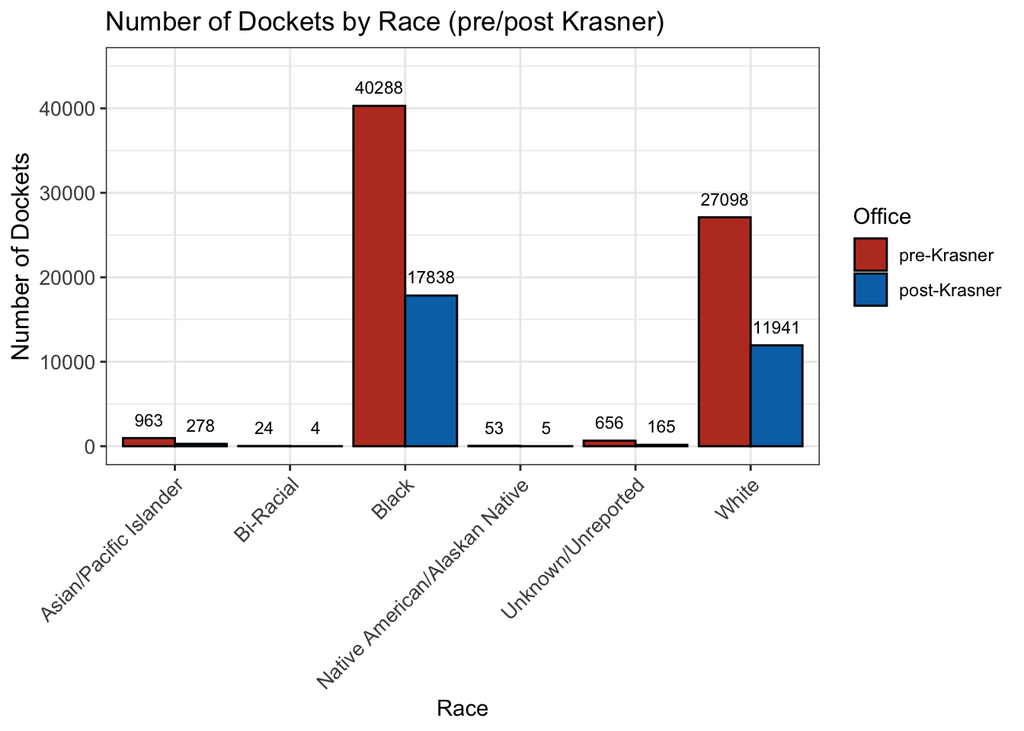

```r
ggplot(displo_plot_df,aes(x=race,fill=timeframe)) +
  geom_bar(position="dodge",color="black") +
  geom_text(stat='count', aes(label=..count..), vjust=-1, position = position_dodge(0.9), size=3) +
  ylim(0,45000) +
  theme_bw() + scale_fill_nejm() +
  labs(title = "Number of Dockets by Race (pre/post Krasner)",
       fill = "Office") +
  xlab("Race") + ylab("Number of Dockets") +
  theme(axis.text.x = element_text(angle = 45,hjust = 1,size = 10),
        axis.text.y = element_text(size = 10),
        axis.title.y = element_text(size = 12))
```

In all but unknown/unreported race, larger proportion of dockets with a negotiated guilty plea.

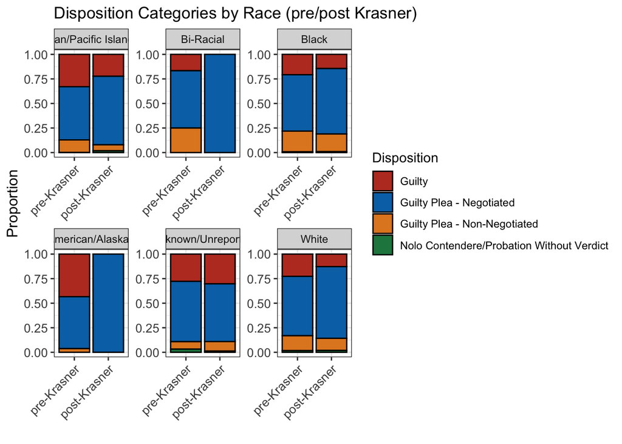

```r
ggplot(displo_plot_df,aes(x=timeframe,fill=disposition)) +
  geom_bar(position="fill",color="black") +
  theme_bw() + scale_fill_nejm() + facet_wrap(~race, scales = "free") +
  labs(title = "Disposition Categories by Race (pre/post Krasner)", fill = "Disposition") + xlab("") + ylab("Proportion") +
  theme(axis.text.x = element_text(angle = 45,hjust = 1,size = 10),
        axis.text.y = element_text(size = 10),
        axis.title.y = element_text(size = 12))
```

### Statutes Analysis (by offenses)

Questions of Interest: - What statutes are represented “before” and “after”? Notes: - Includes NA for disposition, which may include charges that are dropped

Evaluating statute categories by % of offenses in category “before” and “after”.

```r
# calculate the percent of offenses in each statute category
statute_off_percent <- offenses_details %>%
  group_by(timeframe,statute_name,statute_description) %>%
  count(timeframe,statute_name,statute_description,name="Number") %>%
  group_by(timeframe) %>%
  mutate(Percent = (Number/sum(Number)) * 100) %>%
  dplyr::select(timeframe, statute_name, statute_description, Percent) %>%
  spread(timeframe, Percent) %>%
  drop_na() %>%
  mutate(Percent_Diff = `after` - `before`,
         Percent_FC = `after` / `before`) %>%
  mutate(Change = factor(ifelse(Percent_Diff > 0 , "Increase","Decrease"),
                         levels = c("Increase","Decrease")),
         title_id = gsub("\\ .*","",statute_name)) %>%
  merge(.,statute_titles, by = "title_id")

# identity most different statute categories (pre vs. post)
statutes_off_percent_sub <- statute_off_percent %>%
  dplyr::filter(before > .5 | after > .5,
                Percent_FC > 1.5 | Percent_FC < 0.75) %>%
  #dplyr::filter(abs(Percent_Diff)>.25) %>%
  mutate(Change = factor(Change, levels = c("Decrease","Increase")))

# statute_off_percent %>%
#   dplyr::filter(grepl("18 § 5902",statute_name))
```

Plotting by percentage of offenses per statute category (before AND after).

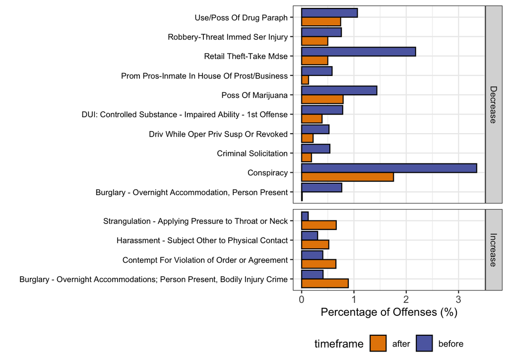

```r
# plot group bar (pre and post) by number of offenses per statute
## need to change from "wide" to "long" format
ggplot(statutes_off_percent_sub %>%
         pivot_longer(cols = c("before","after"),names_to="timeframe",
                      values_to="Percent") %>%
         mutate(timeframe = factor(timeframe,levels = c("after","before"))),
       aes(y=statute_description,x=Percent,fill=timeframe))+
  geom_bar(position="dodge",stat="identity",color="black") +
  theme_bw() + scale_fill_manual(values = c("#E58605","#5D6AB0")) +
  facet_grid(Change ~ ., scales = "free", space = "free") +
  ylab("") + xlab("Percentage of Offenses (%)") +
  theme(axis.text.x = element_text(size = 10),
        axis.text.y = element_text(size = 8,color="black"),
        axis.title.y = element_text(size = 12),
        legend.position = "bottom")
```

```r
ggsave(paste0("figures/statutes/",Sys.Date(),"_Offenses-Statutes-Percent.png"),height = 4,width = 8, device = "png", dpi=700)
```

Plotting by percentage of offenses per statute category (difference in percent, after - before).

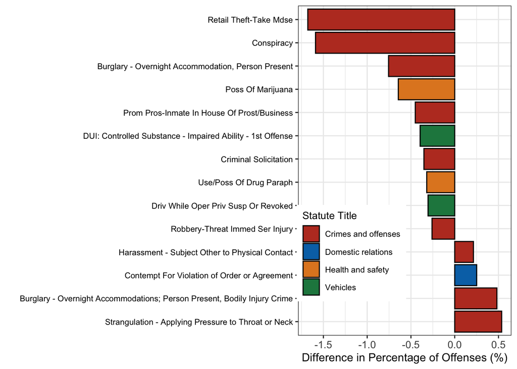

```r
ggplot(statutes_off_percent_sub,
       aes(y= reorder(statute_description, -Percent_Diff),x=Percent_Diff,fill=title_text)) +
  geom_bar(stat="identity", color="black") +
  theme_bw() + scale_fill_nejm() +
  labs(fill = "Statute Title") +
  ylab("") + xlab("Difference in Percentage of Offenses (%)") +
  theme(axis.text.x = element_text(size = 10),
        axis.text.y = element_text(size = 8,color="black"),
        axis.title.y = element_text(size = 12),
        legend.text = element_text(size = 8),
        legend.title = element_text(size = 10),
        legend.position = c(0.25, 0.25))
```

```r
ggsave(paste0("figures/statutes/",Sys.Date(),"_Offenses-Statutes-Percent-Difference.png"),height = 4,width = 8, device = "png", dpi=700)
```

Plotting by percentage of offenses per statute category (fold change in percent, after / before).

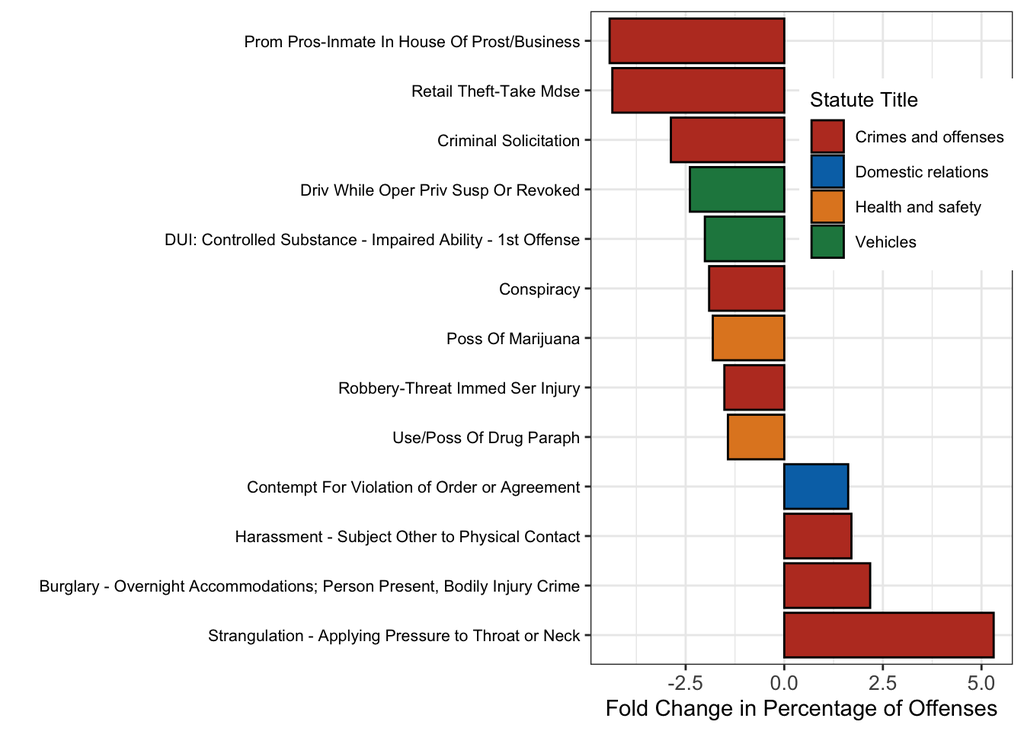

```r
# plot fold change in number of dockets per statute (pre vs. post)
statutes_off_percent_sub <- statutes_off_percent_sub %>%
  mutate(Percent_FC_greaterThanOne = ifelse(Percent_FC > 1, Percent_FC, -(1/Percent_FC)),
         OverTenFC = ifelse(abs(Percent_FC_greaterThanOne) > 10, "OverTenFC","UnderTenFC"))

ggplot(statutes_off_percent_sub %>% dplyr::filter(OverTenFC == "UnderTenFC"),
       aes(y=reorder(statute_description, -Percent_FC_greaterThanOne),x=Percent_FC_greaterThanOne,fill=title_text)) +
  geom_bar(stat="identity", color="black") +
  theme_bw() + scale_fill_nejm() +
  labs(fill = "Statute Title") +
  ylab("") + xlab("Fold Change in Percentage of Offenses") +
  theme(axis.text.x = element_text(size = 10),
        axis.text.y = element_text(size = 8,color="black"),
        axis.title.y = element_text(size = 12),
        legend.text = element_text(size = 8),
        legend.title = element_text(size = 10),
        legend.position = c(0.75, 0.75))
```

```r
ggsave(paste0("figures/statutes/",Sys.Date(),"_Offenses-Statutes-Percent-FoldChange.png"),height = 4,width = 8, device = "png", dpi=700)
```

### Statutes Analysis (by dockets)

Questions of Interest: - What statutes are represented “before” and “after”?

Evaluating by percentage of dockets per statute category.

```r
# deteremine number of dockets with given statute; difference pre vs. post; fold change pre vs. post
statute_percent <- docket_charges %>%
  dplyr::mutate(timeframe = ifelse(timeframe == "pre-Krasner","before","after")) %>%
  group_by(timeframe,statute) %>%
  count(timeframe,statute,name="Number") %>%
  group_by(timeframe) %>%
  mutate(Percent = (Number/sum(Number)) * 100) %>%
  dplyr::select(timeframe, statute, Percent) %>%
  spread(timeframe, Percent) %>%
  drop_na() %>%
  mutate(Percent_Diff = `after` - `before`,
         Percent_FC = `after` / `before`) %>%
  mutate(Change = factor(ifelse(Percent_Diff > 0 , "Increase","Decrease"),
                         levels = c("Increase","Decrease"))) %>%
  merge(.,statute_df,by="statute")

# identity most different statute categories (pre vs. post)
statutes_percent_sub <- statute_percent %>%
  dplyr::filter(before > .25 | after > .25,
                Percent_FC > 1.5 | Percent_FC < 0.75) %>%
  mutate(Change = factor(Change, levels = c("Decrease","Increase")))
```

Plotting by percentage of dockets per statute category (before AND after).

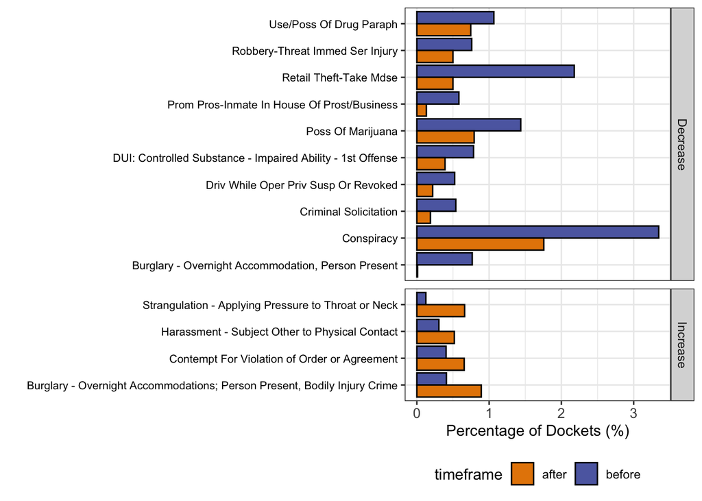

```r
ggplot(statutes_off_percent_sub %>%
         pivot_longer(cols = c("before","after"),names_to="timeframe",
                      values_to="Percent") %>%
         mutate(timeframe = factor(timeframe,levels = c("after","before"))),
       aes(y=statute_description,x=Percent,fill=timeframe))+
  geom_bar(position="dodge",stat="identity",color="black") +
  theme_bw() + scale_fill_manual(values = c("#E58605","#5D6AB0")) +
  facet_grid(Change ~ ., scales = "free", space = "free") +
  ylab("") + xlab("Percentage of Dockets (%)") +
  theme(axis.text.x = element_text(size = 10),
        axis.text.y = element_text(size = 8,color="black"),
        axis.title.y = element_text(size = 12),
        legend.position = "bottom")
```

```r
ggsave(paste0("figures/statutes/",Sys.Date(),"_Dockets-Statutes-Percent.png"),height = 4,width = 8, device = "png", dpi=700)
```

Plotting by percentage of dockets per statute category (difference in percent, after - before).

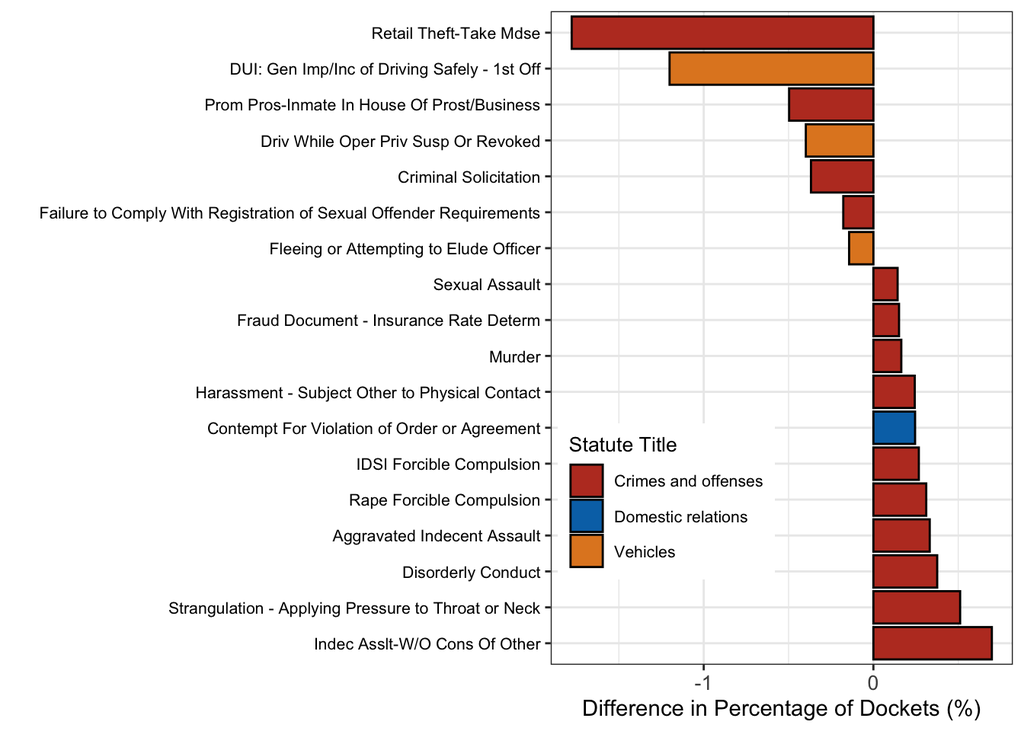

```r
ggplot(statutes_percent_sub,
       aes(y= reorder(statute_description, -Percent_Diff),x=Percent_Diff,fill=title_text)) +
  geom_bar(stat="identity", color="black") +
  theme_bw() + scale_fill_nejm() +
  labs(fill = "Statute Title") +
  ylab("") + xlab("Difference in Percentage of Dockets (%)") +
  theme(axis.text.x = element_text(size = 10),
        axis.text.y = element_text(size = 8,color="black"),
        axis.title.y = element_text(size = 12),
        legend.text = element_text(size = 8),
        legend.title = element_text(size = 10),
        legend.position = c(0.25, 0.25))
```

```r
ggsave(paste0("figures/statutes/",Sys.Date(),"_Dockets-Statutes-Percent-Difference.png"),height = 4,width = 8, device = "png", dpi=700)
```

Plotting by percentage of dockets per statute category (fold change in percent, after / before).

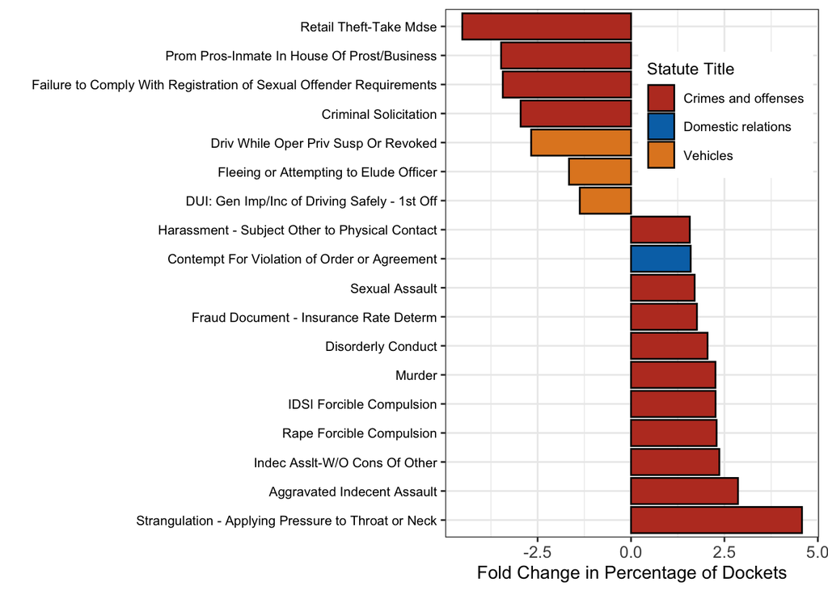

```r
# plot fold change in number of dockets per statute (pre vs. post)
statutes_percent_sub <- statutes_percent_sub %>%
  mutate(Percent_FC_greaterThanOne = ifelse(Percent_FC > 1, Percent_FC, -(1/Percent_FC)))

ggplot(statutes_percent_sub,
       aes(y=reorder(statute_description, -Percent_FC_greaterThanOne),x=Percent_FC_greaterThanOne,fill=title_text)) +
  geom_bar(stat="identity", color="black") +
  theme_bw() + scale_fill_nejm() +
  labs(fill = "Statute Title") +
  ylab("") + xlab("Fold Change in Percentage of Dockets") +
  theme(axis.text.x = element_text(size = 10),
        axis.text.y = element_text(size = 8,color="black"),
        axis.title.y = element_text(size = 12),
        legend.text = element_text(size = 8),
        legend.title = element_text(size = 10),
        legend.position = c(0.75, 0.8))
```

```r
ggsave(paste0("figures/statutes/",Sys.Date(),"_Dockets-Statutes-Percent-FoldChange.png"),height = 4,width = 8, device = "png", dpi=700)
```

### Trends in Minimum Bail (by dockets, race)

- Minimum bail ($) pre/post Krasner, separated by race and grade

Subset dataset on misdemeanors and felonies, and combine ungraded and third-degree categories.

```r
grade.subset <- c("M","M3","M2","M1","F","F3","F2","F1")
docket_charges_race <- docket_charges %>%
  dplyr::filter(race %in% c("Black","White"),
                grade %in% grade.subset) %>%
  drop_na(min_bail,min_sentencing) %>%  # note: this plot is dramatically skews minimum bail upwards...
                                        # if NOT filtering for NA in min_sentencing
                                        # same trend though
  mutate(
    grade = case_when(
      grade %in% c("M", "M3") ~ "M3/M",
      grade %in% c("F", "F3") ~ "M3/M",
      grade %in% c("M2","M1","F2","F1") ~ grade,
    ) %>%
      factor(levels = c("M3/M", "M2", "M1", "F3/F", "F2", "F1")),
    timeframe = case_when(
      timeframe == "pre-Krasner" ~ "before",
      timeframe == "post-Krasner" ~ "after",
    ) %>%
      factor(levels = c("before", "after"))
  )
```

F1 minimum bail becomes more equitable between Black/White after Krasner takes office.

```r
docket_charges_race %>%
  group_by(timeframe,race,grade) %>%
  summarize(median=median(min_bail),mean=mean(min_bail),n=n())
```

```
## # A tibble: 20 x 6
## # Groups:   timeframe, race [4]
##    timeframe race  grade median    mean     n
##    <fct>     <chr> <fct>  <dbl>   <dbl> <int>
##  1 before    Black M3/M    5000  45789.  6641
##  2 before    Black M2      5000  35959    973
##  3 before    Black M1     10000  85321.  1670
##  4 before    Black F2     50000 120020.  1686
##  5 before    Black F1    150000 266877.  2527
##  6 before    White M3/M    5000  29711.  5652
##  7 before    White M2      5000  18851.   556
##  8 before    White M1      3500  42183.  1017
##  9 before    White F2     25000  80805.   832
## 10 before    White F1     50000 177389.   845
## 11 after     Black M3/M    5000  36650.  2631
## 12 after     Black M2      5000  31620.   547
## 13 after     Black M1     10000  60197.   703
## 14 after     Black F2     25000  74130.   698
## 15 after     Black F1    100000 174470.  1223
## 16 after     White M3/M    5000  38831.  2490
## 17 after     White M2      5000  21219.   229
## 18 after     White M1      3000  36469.   396
## 19 after     White F2     15000 124890.   329
## 20 after     White F1     75000 166244.   422
```

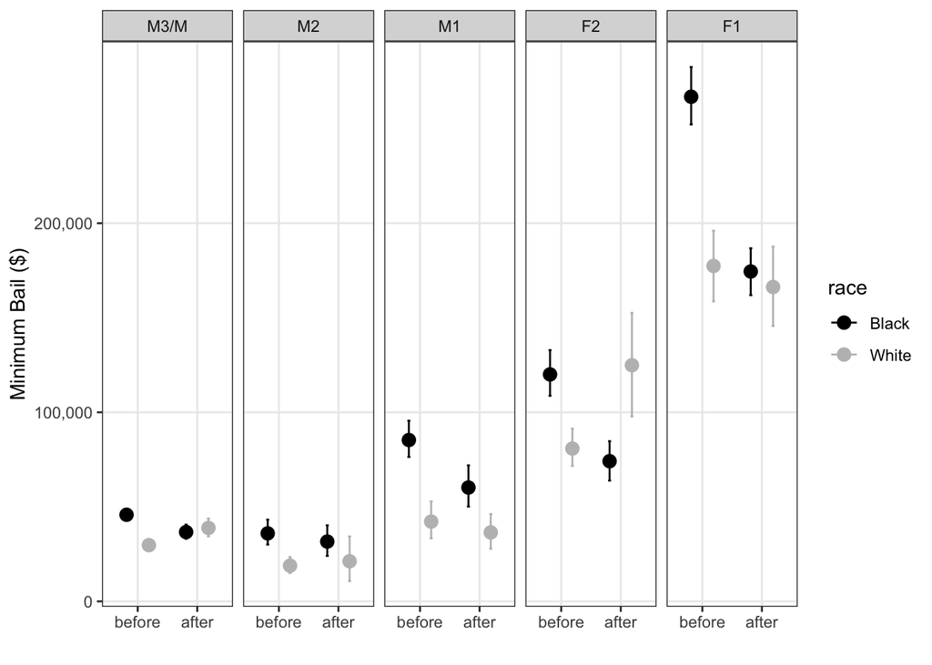

```r
# plot grade by min bail, race, and timeframe
ggplot(docket_charges_race,aes(x=timeframe,y=min_bail,color=race, fill=race)) +
  scale_y_continuous(label=comma) +
  facet_wrap(~grade, nrow = 1) +
  scale_color_manual(values = c("black", "gray")) +
  scale_fill_manual(values = c("black", "gray")) +
  stat_summary(fun.data=mean_cl_boot, geom="errorbar", width=0.1, position=position_dodge(width = 0.75)) +
  stat_summary(fun=mean, geom="point", size=3, position=position_dodge(width = 0.75)) +
  ylab("Minimum Bail ($)") + xlab("") +
  theme_bw() + theme(panel.grid.minor = element_blank())
```

```r
ggsave(paste0("figures/bail/",Sys.Date(),"_Dockets-Bail-Misdemeanor-Felony.png"),height = 3,width = 8, device = "png", dpi=700)
```

Closer look at % statutes (F1, before) between races.

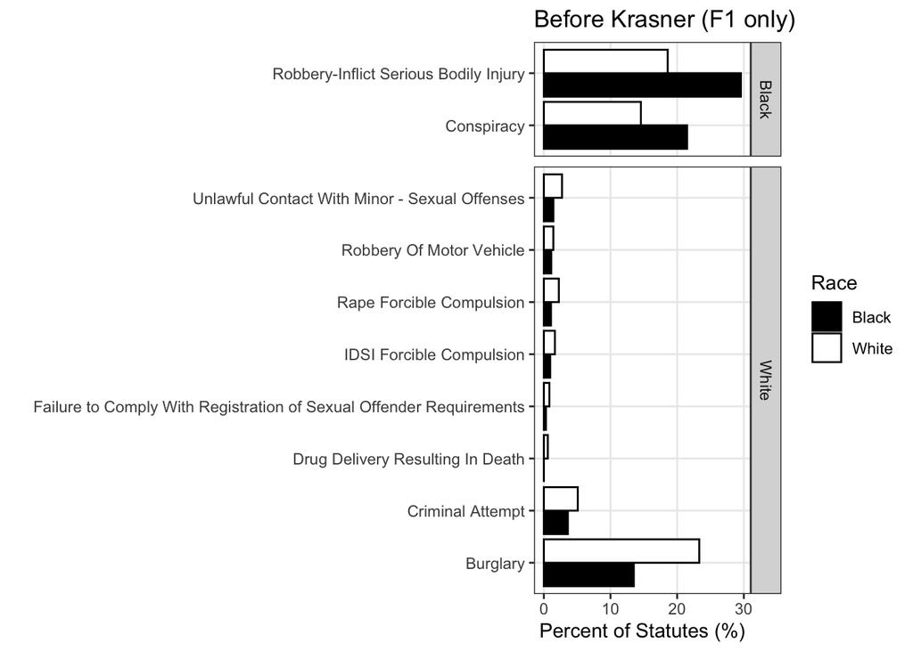

```r
# plot statutes by race in F1 before
docket_charges_race_statBefore <- docket_charges_race %>%
  dplyr::filter(grade == "F1", timeframe=="before") %>%
  group_by(race,statute) %>%
  count(race,statute,name="Number") %>%
  group_by(race) %>%
  mutate(Percent = (Number/sum(Number))*100) %>%
  dplyr::select(race,statute,Percent) %>%
  spread(race,Percent) %>% replace_na(list(Black = 0, White = 0)) %>%
  mutate(Percent_Diff_BW = Black - White,
         Percent_FC_BW = Black / White) %>%
  merge(.,statute_df,by="statute")

statBefore_filter <- docket_charges_race_statBefore %>%
  dplyr::filter(Black > .5 | White > .5,
                Percent_FC_BW > 1.25 | Percent_FC_BW < 0.8) %>%
  mutate(Change = factor(ifelse(Percent_Diff_BW > 0 , "Black","White"),
                         levels = c("Black","White"))) %>%
  dplyr::select(statute_description,Black,White,Change) %>%
  melt(.,id.vars=c("statute_description","Change"))

ggplot(statBefore_filter,aes(y=statute_description, x = value, color=variable, fill=variable)) +
  geom_bar(stat="identity",position="dodge",color="black") +
  facet_grid(Change ~., scales = "free", space="free") +
  scale_fill_manual(values = c("Black","White")) +
  labs(title = "Before Krasner (F1 only)", fill = "Race") +
  xlab("Percent of Statutes (%)") + ylab("") +
  theme_bw() + theme(panel.grid.minor = element_blank())
```

```r
ggsave(paste0("figures/bail/",Sys.Date(),"_Dockets-Bail-F1-Before-Statutes.png"),height = 4,width = 8, device = "png", dpi=700)
```

Closer look at % statutes (F1, after) between races.

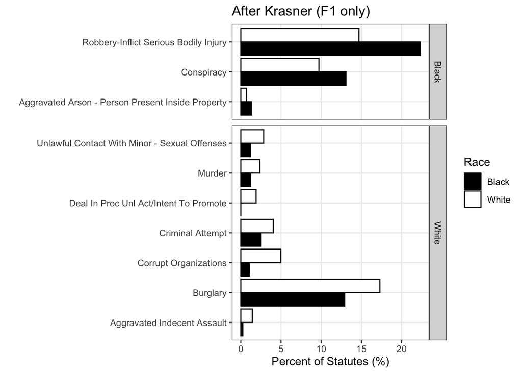

```r
# plot statutes by race in F1 before
docket_charges_race_statAfter <- docket_charges_race %>%
  dplyr::filter(grade == "F1", timeframe=="after") %>%
  group_by(race,statute) %>%
  count(race,statute,name="Number") %>%
  group_by(race) %>%
  mutate(Percent = (Number/sum(Number))*100) %>%
  dplyr::select(race,statute,Percent) %>%
  spread(race,Percent) %>% replace_na(list(Black = 0, White = 0)) %>%
  mutate(Percent_Diff_BW = Black - White,
         Percent_FC_BW = Black / White) %>%
  merge(.,statute_df,by="statute")

statAfter_filter <- docket_charges_race_statAfter %>%
  dplyr::filter(Black > .5 | White > .5,
                Percent_FC_BW > 1.25 | Percent_FC_BW < 0.8) %>%
  mutate(Change = factor(ifelse(Percent_Diff_BW > 0 , "Black","White"),
                         levels = c("Black","White"))) %>%
  dplyr::select(statute_description,Black,White,Change) %>%
  melt(.,id.vars=c("statute_description","Change"))

ggplot(statAfter_filter,aes(y=statute_description, x = value, color=variable, fill=variable)) +
  geom_bar(stat="identity",position="dodge",color="black") +
  facet_grid(Change ~., scales = "free", space="free") +
  scale_fill_manual(values = c("Black","White")) +
  labs(title = "After Krasner (F1 only)", fill = "Race") +
  xlab("Percent of Statutes (%)") + ylab("") +
  theme_bw() + theme(panel.grid.minor = element_blank())
```

```r
ggsave(paste0("figures/bail/",Sys.Date(),"_Dockets-Bail-F1-After-Statutes.png"),height = 4,width = 8, device = "png", dpi=700)
```

### Minimum Sentencing (by dockets)

- Check minimum sentencing by probation and confinement

```r
docket_charges_race %>%
  dplyr::filter(sentence_type == "Probation") %>%
  group_by(timeframe,race,grade) %>%
  summarize(median=median(min_sentencing),mean=mean(min_sentencing),n=n())
```

```
## # A tibble: 20 x 6
## # Groups:   timeframe, race [4]
##    timeframe race  grade median  mean     n
##    <fct>     <chr> <fct>  <dbl> <dbl> <int>
##  1 before    Black M3/M     273  310.  1439
##  2 before    Black M2       273  324.   415
##  3 before    Black M1       273  320.   364
##  4 before    Black F2       365  393.    33
##  5 before    Black F1      4383 3585.    52
##  6 before    White M3/M     273  293.  1694
##  7 before    White M2       273  326.   287
##  8 before    White M1       273  298.   277
##  9 before    White F2       365  356.    10
## 10 before    White F1      4383 3201.    17
## 11 after     Black M3/M     273  332.   651
## 12 after     Black M2       365  325.   252
## 13 after     Black M1       365  358.   166
## 14 after     Black F2       365  437.    33
## 15 after     Black F1       365 3098.    60
## 16 after     White M3/M     273  333.   806
## 17 after     White M2       365  330.   118
## 18 after     White M1       365  367.    85
## 19 after     White F2       365  365     15
## 20 after     White F1       365  744.    13
```

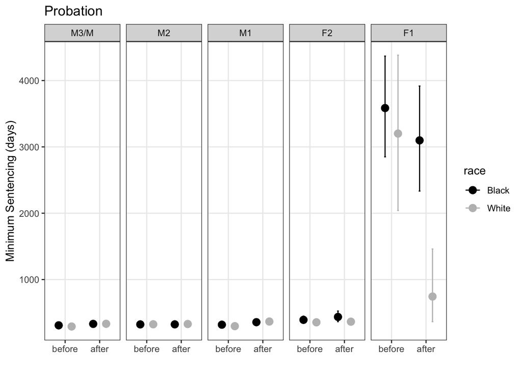

```r
# min_sentencing by PROBATION
ggplot(docket_charges_race %>%
         dplyr::filter(sentence_type == "Probation"),
       aes(x=timeframe,y=min_sentencing,color=race, fill=race)) +
  #scale_y_log10() +
  facet_wrap(~grade, nrow=1) +
  scale_color_manual(values = c("black", "gray")) +
  scale_fill_manual(values = c("black", "gray")) +
    labs(title = "Probation") +
  stat_summary(fun.data=mean_cl_boot, geom="errorbar", width=0.1, position=position_dodge(width = 0.75)) +
  stat_summary(fun=mean, geom="point", size=3, position=position_dodge(width = 0.75)) +
  stat_summary(fun=mean, geom="point", size=3, position=position_dodge(width = 0.75)) +
  ylab("Minimum Sentencing (days)") + xlab("") +
  theme_bw() +  theme(panel.grid.minor = element_blank())
```

```r
ggsave(paste0("figures/sentencing/",Sys.Date(),"_MinSentencing-Probation-Race.png"),height = 3,width = 8, device = "png", dpi=700)
```

```r
docket_charges_race %>%
  dplyr::filter(sentence_type == "Confinement") %>%
  group_by(timeframe,race,grade) %>%
  summarize(median=median(min_sentencing),mean=mean(min_sentencing),n=n())
```

```
## # A tibble: 20 x 6
## # Groups:   timeframe, race [4]
##    timeframe race  grade median  mean     n
##    <fct>     <chr> <fct>  <dbl> <dbl> <int>
##  1 before    Black M3/M     273  296.  5119
##  2 before    Black M2       182  222.   558
##  3 before    Black M1       273  310.  1305
##  4 before    Black F2       349  546.  1638
##  5 before    Black F1       913 1185.  2474
##  6 before    White M3/M     182  249.  3836
##  7 before    White M2       182  192.   269
##  8 before    White M1       182  236.   739
##  9 before    White F2       349  518.   812
## 10 before    White F1       730 1027.   826
## 11 after     Black M3/M     273  283.  1954
## 12 after     Black M2       182  213.   295
## 13 after     Black M1       243  286.   537
## 14 after     Black F2       349  458.   655
## 15 after     Black F1       730 1056.  1163
## 16 after     White M3/M     273  311.  1632
## 17 after     White M2       182  202.   111
## 18 after     White M1       182  246.   311
## 19 after     White F2       349  391.   310
## 20 after     White F1       913 1216.   409
```

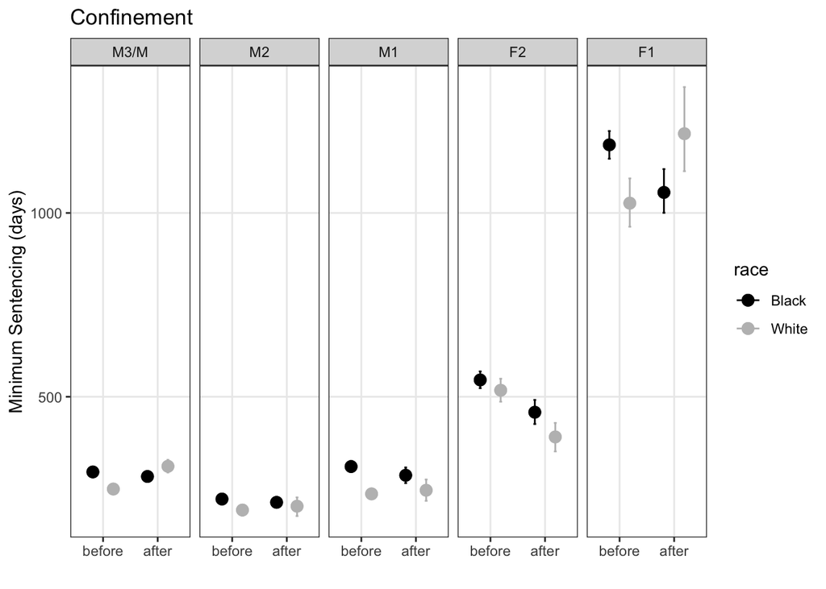

```r
# min_sentencing by CONFINEMENT
ggplot(docket_charges_race %>%
         dplyr::filter(sentence_type == "Confinement"),
       aes(x=timeframe,y=min_sentencing,color=race, fill=race)) +
  #scale_y_log10() +
  facet_wrap(~grade, nrow=1) +
  scale_color_manual(values = c("black", "gray")) +
  scale_fill_manual(values = c("black", "gray")) +
  labs(title = "Confinement") +
  stat_summary(fun.data=mean_cl_boot, geom="errorbar", width=0.1, position=position_dodge(width = 0.75)) +
  stat_summary(fun=mean, geom="point", size=3, position=position_dodge(width = 0.75)) +
  stat_summary(fun=mean, geom="point", size=3, position=position_dodge(width = 0.75)) +
  ylab("Minimum Sentencing (days)") + xlab("") +
  theme_bw() +  theme(panel.grid.minor = element_blank())
```

```r
ggsave(paste0("figures/sentencing/",Sys.Date(),"_MinSentencing-Confinement-Race.png"),height = 3,width = 8, device = "png", dpi=700)
```